# 机器学习投资分析－GMM+HMM (高斯混合模型＋隐形马尔可夫模型）

薛剑波

2015.10.06

# 1.市场状态

金融市场通常会呈现2，3种市场状态（牛市， 熊市，震荡市）。每种市场状态分别代表的市场指数不同的特性：

- 牛市状态下，上涨的幅度和天数要超过下跌的幅度和天数。
- 熊市状态下则正好相反， 下跌的幅度和天数要高于上涨。
- 震动市状态，则是一个无方向性的状态， 上涨和下跌的天数和幅度不相上下。

我们可以将中证500从2013年7月至2015年9月的净值曲线分为如上几个状态：

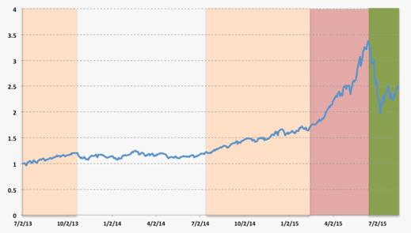

```r
source("gmmhmm.R")
data <- read.csv("data/NAV_5ETFs.csv")
zz500 <- as.xts(data[, 2], order.by=strptime(data[, 1], format="%Y-%m-%d", tz=""))
zz500 <- na.omit(cbind(zz500, Return.calculate(zz500)))
colnames(zz500) <- c('zz500', 'zz500.ret')
```

将中证500指数的日回报数据进行分析，我们可以看到它并不是一个理论的高斯正态分布，表现出负对称性和左端的厚尾。

```
##                 zz500.ret
## Observations    1602.0000
## NAs                0.0000
## Minimum           -0.0843
## Quartile 1        -0.0087
## Median             0.0026
## Arithmetic Mean    0.0009
## Geometric Mean     0.0007
## Quartile 3         0.0128
## Maximum            0.0987
## SE Mean            0.0005
## LCL Mean (0.95)   -0.0001
## UCL Mean (0.95)    0.0019
## Variance           0.0004
## Stdev              0.0203
## Skewness          -0.4888
## Kurtosis           2.2795
```

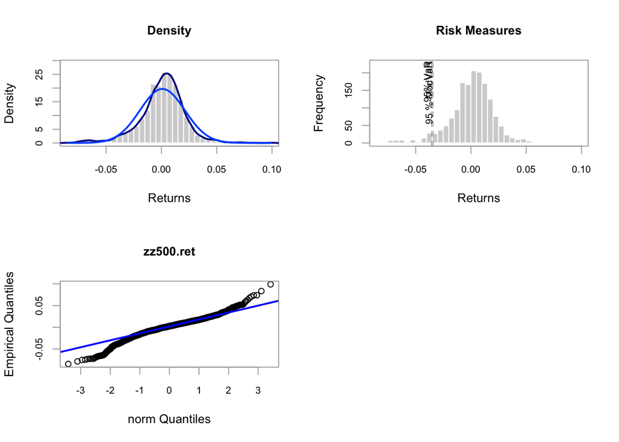

因此，如果我们将市场指数（如沪深300）日回报（daily return），划分为如上所述的3个市场状态的3组数据， 则它们应该会整体呈现出如下特征：

- 牛市状态下， 平均回报率高（rate of return > 0), 波动性小， positive skewness
- 熊市状态下， 平均回报率低， 波动性大， negative skewness
- 震荡市状态下， 平均回报率趋近零， 波动性和skewness不定

# 2. 通过机器学习的方法对指数数据分类

所以如果我们可以通过机器学习以及相关的分类模型的方法， 对市场数据进行分析， 我们就可以更深入的了解当前的市场状态， 并作出相应的投资决策。

这里我们使用两者机器学习领域常用的模型：

- 1. 高斯混合模型（Gaussian Mixture Model － GMM）
- 2. 隐形马尔可夫模型（Hidden Markov Model - HMM)

首先我们简要介绍一下什么是高斯混合模型GMM。

GMM模型可以如何帮我们实现对市场数据的分析呢？ 首先， 当我们认为市场存在n个状态（n＝2是牛熊市， n=3是牛熊市和震荡市， 当然n可以为任何>1的自然数），GMM分析所有的数据，并找到最佳的n个市场状态的中心点（中心点定义为该市场状态下的平均回报率r和波动性$\sigma$。 其次， GMM根据每个数据点距离n个分组中心点的距离（距离是由我们选定的每个分组的概率分布pdf方程决定的）， 告诉我们该数据点属于哪个分组的几率最高。

也就是说，我们只要告诉GMM我们在寻找n=3个市场状态， 以及每个市场状态下数据的概率分布方程（Probability Distribution Function）是什么：通常选择正态分布（Normal Distribution）， GMM就会自动帮我们将市场数据分成几类。

## 2.2 单一市场指数的HMM分析

基于上述的分析， 我们用R中间的depmix软件包来分析中证500最近2008至2015年的数据。

### 测试1: 市场状态＝2

我们选择2个市场状态，来看看HMM是否可以有效的将市场数据分开：

```r
data_case1 <- zz500$zz500.ret
gmm <- gmm_training(data_training = data_case1, nstate = 2)
hmm <- hmm_training(gmm, data_case1, data_case1)
```

```
## [1] 1.429506
##   zz500.ret zz500.ret.1
##  -0.5732578   2.1416038
```

```r
ret_regime1 <- hmm$hmm_ret_regime[,1]
ret_regime1 <- ret_regime1[ret_regime1 != 0]
ret_regime2 <- hmm$hmm_ret_regime[,2]
ret_regime2 <- ret_regime2[ret_regime2 != 0]
```

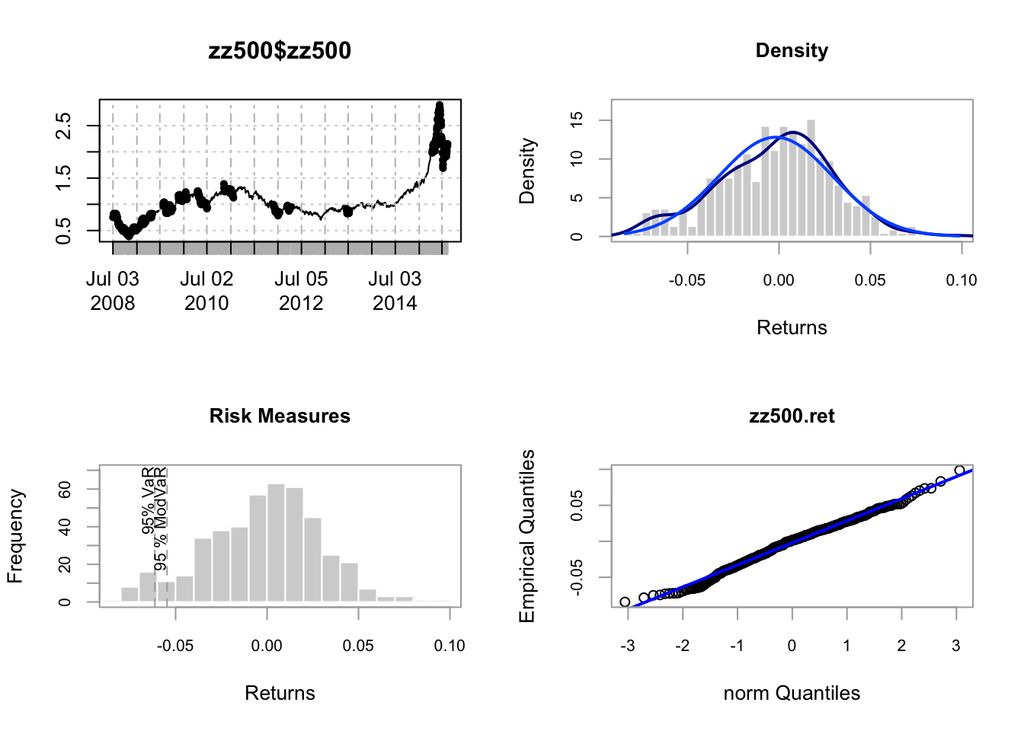

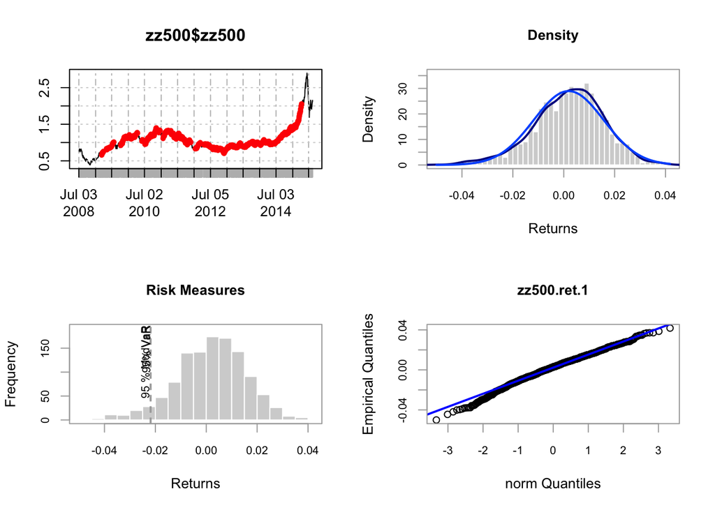

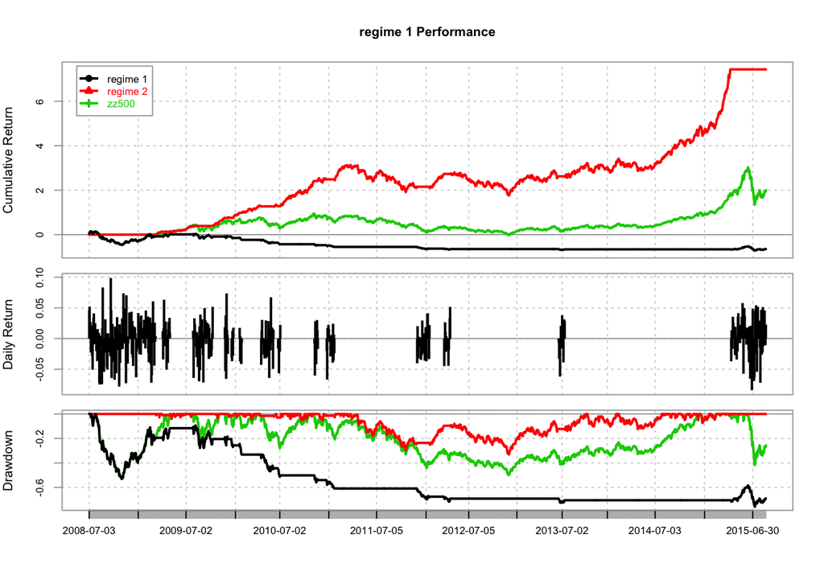

```
##                             regime 1   regime 2     zz500
## Annualized Return         -0.1502000  0.3985000  0.188500
## Annualized Std Dev         0.2619000  0.1861000  0.321900
## Annualized Sharpe (Rf=0%) -0.5733000  2.1416000  0.585700
## Monthly Std Dev            0.0165000  0.0117000  0.020300
## Skewness                  -0.5894000 -0.3040000 -0.488800
## Kurtosis                  10.6360000  4.5824000  5.279500
## Excess kurtosis            7.6360000  1.5824000  2.279500
## Sample skewness           -0.5905000 -0.3045000 -0.489700
## Sample excess kurtosis     7.6636000  1.5911000  2.290400
## Worst Drawdown             0.7572155  0.3312005  0.530865
```

### 测试2: 市场状态＝5

如果我们将选择的市场状态从2个增加到5个， HMM模型分析的效果则大大的提升了。

```r
data_case2 <- zz500$zz500.ret
gmm <- gmm_training(data_training = data_case2, nstate = 5)
hmm <- hmm_training(gmm, data_case2, data_case2)
```

```
## [1] 1.429506
##   zz500.ret zz500.ret.1 zz500.ret.2 zz500.ret.3 zz500.ret.4
##   -2.195355   -4.160671    8.629597    6.953163    2.264130
```

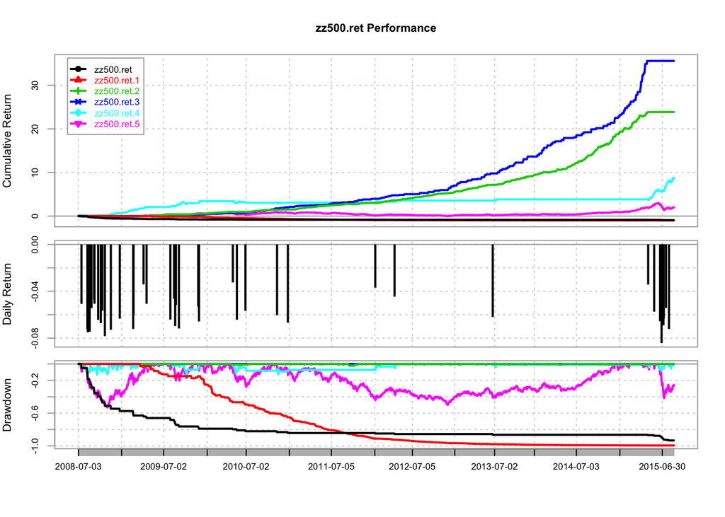

```r
ret_regimes <- cbind.xts(hmm$hmm_ret_regime, zz500$zz500.ret)
charts.PerformanceSummary(ret_regimes)
```

```r
table.Stats(ret_regimes)
```

```
##                 zz500.ret zz500.ret.1 zz500.ret.2 zz500.ret.3 zz500.ret.4
## Observations    1602.0000   1602.0000   1602.0000   1602.0000   1602.0000
## NAs                0.0000      0.0000      0.0000      0.0000      0.0000
## Minimum           -0.0843     -0.0501     -0.0107      0.0000     -0.0495
## Quartile 1         0.0000      0.0000      0.0000      0.0000      0.0000
## Median             0.0000      0.0000      0.0000      0.0000      0.0000
## Arithmetic Mean   -0.0016     -0.0033      0.0020      0.0023      0.0015
## Geometric Mean    -0.0017     -0.0033      0.0020      0.0022      0.0014
## Quartile 3         0.0000      0.0000      0.0023      0.0000      0.0000
## Maximum            0.0000      0.0297      0.0213      0.0418      0.0987
## SE Mean            0.0002      0.0002      0.0001      0.0002      0.0003
## LCL Mean (0.95)   -0.0021     -0.0037      0.0018      0.0019      0.0009
## UCL Mean (0.95)   -0.0011     -0.0028      0.0023      0.0026      0.0021
## Variance           0.0001      0.0001      0.0000      0.0000      0.0001
## Stdev              0.0100      0.0086      0.0048      0.0069      0.0120
## Skewness          -6.1279     -2.1469      1.5745      3.0264      1.9290
## Kurtosis          36.7097      6.0265      2.4183      8.2670     12.1627
##                 zz500.ret.5
## Observations      1602.0000
## NAs                  0.0000
## Minimum             -0.0843
## Quartile 1          -0.0087
## Median               0.0026
## Arithmetic Mean      0.0009
## Geometric Mean       0.0007
## Quartile 3           0.0128
## Maximum              0.0987
## SE Mean              0.0005
## LCL Mean (0.95)     -0.0001
## UCL Mean (0.95)      0.0019
## Variance             0.0004
## Stdev                0.0203
## Skewness            -0.4888
## Kurtosis             2.2795
```

```r
rbind(table.AnnualizedReturns(ret_regimes), table.Distributions(ret_regimes), maxDrawdown(ret_regimes))
```

```
##                            zz500.ret zz500.ret.1 zz500.ret.2 zz500.ret.3
## Annualized Return         -0.3468000  -0.5648000  0.65760000      0.7615
## Annualized Std Dev         0.1580000   0.1357000  0.07620000      0.1095
## Annualized Sharpe (Rf=0%) -2.1954000  -4.1607000  8.62960000      6.9532
## Monthly Std Dev            0.0100000   0.0086000  0.00480000      0.0069
## Skewness                  -6.1279000  -2.1469000  1.57450000      3.0264
## Kurtosis                  39.7097000   9.0265000  5.41830000     11.2670
## Excess kurtosis           36.7097000   6.0265000  2.41830000      8.2670
## Sample skewness           -6.1394000  -2.1510000  1.57740000      3.0321
## Sample excess kurtosis    36.8283000   6.0491000  2.42970000      8.2966
## Worst Drawdown             0.9332653   0.9949524  0.02188159      0.0000
##                           zz500.ret.4 zz500.ret.5
## Annualized Return           0.4318000    0.188500
## Annualized Std Dev          0.1907000    0.321900
## Annualized Sharpe (Rf=0%)   2.2641000    0.585700
## Monthly Std Dev             0.0120000    0.020300
## Skewness                    1.9290000   -0.488800
## Kurtosis                   15.1627000    5.279500
## Excess kurtosis            12.1627000    2.279500
## Sample skewness             1.9326000   -0.489700
## Sample excess kurtosis     12.2045000    2.290400
## Worst Drawdown              0.1306031    0.530865
```

### 测试3.1: 引入其他相关数据

目前我们使用的是指数的日回报率数据。 如果我们在分析数据里面引入日回报率的其他衍生数据， 用HMM模型分析的效果应该可以进一步提升：

```r
data_case3 <- cbind.xts(zz500$zz500.ret, lag(zz500$zz500.ret, 1), lag(zz500$zz500.ret, 5));
colnames(data_case3) <- c("ret", "ret1d", "ret5d")
data_case3 <- na.omit(data_case3)

gmm <- gmm_training(data_training = data_case3, nstate=5)
hmm <- hmm_training(gmm, data_case3, data_case3[,1])
```

```
## [1] 1.31185
##        ret      ret.1      ret.2      ret.3      ret.4
## -0.5259773 -4.2713698  3.7984663  8.6827671  2.9897110
```

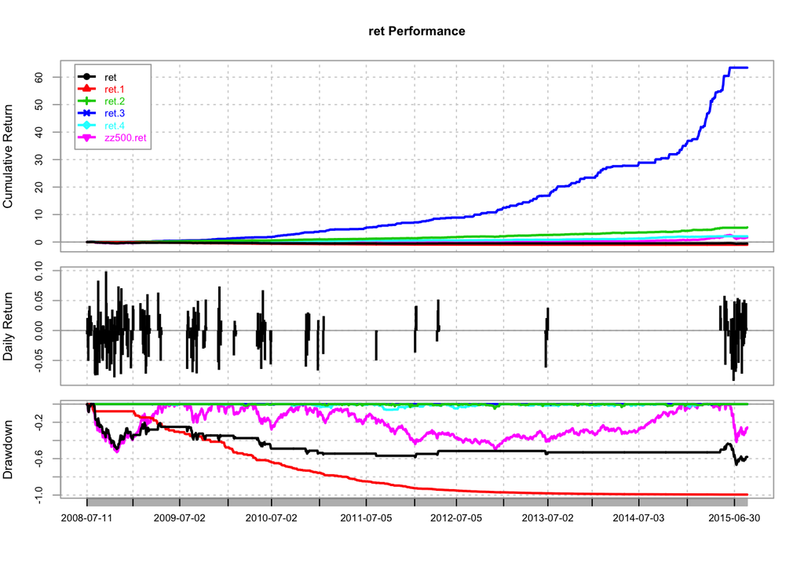

```r
ret_regimes <- cbind.xts(hmm$hmm_ret_regime, zz500$zz500.ret)
charts.PerformanceSummary(ret_regimes)
```

```r
table.Stats(ret_regimes)
```

```
##                       ret     ret.1     ret.2     ret.3     ret.4
## Observations    1597.0000 1597.0000 1597.0000 1597.0000 1597.0000
## NAs                5.0000    5.0000    5.0000    5.0000    5.0000
## Minimum           -0.0843   -0.0449   -0.0222   -0.0089   -0.0157
## Quartile 1         0.0000    0.0000    0.0000    0.0000    0.0000
## Median             0.0000    0.0000    0.0000    0.0000    0.0000
## Arithmetic Mean   -0.0004   -0.0033    0.0012    0.0026    0.0007
## Geometric Mean    -0.0005   -0.0033    0.0012    0.0026    0.0007
## Quartile 3         0.0000    0.0000    0.0000    0.0000    0.0000
## Maximum            0.0987    0.0000    0.0418    0.0386    0.0208
## SE Mean            0.0004    0.0002    0.0001    0.0002    0.0001
## LCL Mean (0.95)   -0.0012   -0.0037    0.0009    0.0023    0.0005
## UCL Mean (0.95)    0.0003   -0.0029    0.0014    0.0030    0.0009
## Variance           0.0002    0.0001    0.0000    0.0000    0.0000
## Stdev              0.0150    0.0084    0.0056    0.0067    0.0041
## Skewness          -0.7385   -2.7134    2.9250    2.6812    1.3849
## Kurtosis          11.5822    6.8055   13.5222    6.7762    4.8536
##                 zz500.ret
## Observations    1602.0000
## NAs                0.0000
## Minimum           -0.0843
## Quartile 1        -0.0087
## Median             0.0026
## Arithmetic Mean    0.0009
## Geometric Mean     0.0007
## Quartile 3         0.0128
## Maximum            0.0987
## SE Mean            0.0005
## LCL Mean (0.95)   -0.0001
## UCL Mean (0.95)    0.0019
## Variance           0.0004
## Stdev              0.0203
## Skewness          -0.4888
## Kurtosis           2.2795
```

```r
rbind(table.AnnualizedReturns(ret_regimes), table.Distributions(ret_regimes), maxDrawdown(ret_regimes))
```

```
##                                  ret      ret.1       ret.2       ret.3
## Annualized Return         -0.1255000 -0.5669000  0.33820000 0.929700000
## Annualized Std Dev         0.2386000  0.1327000  0.08900000 0.107100000
## Annualized Sharpe (Rf=0%) -0.5260000 -4.2714000  3.79850000 8.682800000
## Monthly Std Dev            0.0150000  0.0084000  0.00560000 0.006700000
## Skewness                  -0.7385000 -2.7134000  2.92500000 2.681200000
## Kurtosis                  14.5822000  9.8055000 16.52220000 9.776200000
## Excess kurtosis           11.5822000  6.8055000 13.52220000 6.776200000
## Sample skewness           -0.7399000 -2.7185000  2.93050000 2.686300000
## Sample excess kurtosis    11.6223000  6.8306000 13.56840000 6.801200000
## Worst Drawdown             0.6677039  0.9950196  0.05046339 0.008894986
##                               ret.4 zz500.ret
## Annualized Return         0.1939000  0.188500
## Annualized Std Dev        0.0649000  0.321900
## Annualized Sharpe (Rf=0%) 2.9897000  0.585700
## Monthly Std Dev           0.0041000  0.020300
## Skewness                  1.3849000 -0.488800
## Kurtosis                  7.8536000  5.279500
## Excess kurtosis           4.8536000  2.279500
## Sample skewness           1.3875000 -0.489700
## Sample excess kurtosis    4.8726000  2.290400
## Worst Drawdown            0.0630303  0.530865
```

```r
ema_ret2d <- Return.calculate(TTR::EMA(zz500$zz500, n=2), method = "discrete")
ema_ret10d <- Return.calculate(TTR::EMA(zz500$zz500, n=10), method = "discrete")
data_case3 <- na.omit(cbind.xts(data_case3, ema_ret2d, ema_ret10d))
data_case3 <- na.omit(data_case3)

gmm <- gmm_training(data_training = data_case3, nstate=5)
hmm <- hmm_training(gmm, data_case3, data_case3[,1])
```

```
## [1] 1.386971
##        ret      ret.1      ret.2      ret.3      ret.4
##  2.3073128  1.3331015 -3.5106615  0.1276446  5.2093536
```

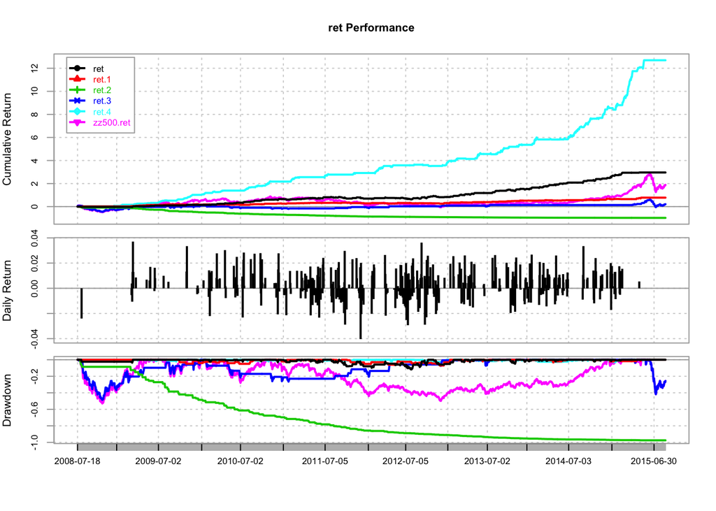

```r
ret_regimes <- cbind.xts(hmm$hmm_ret_regime, zz500$zz500.ret)
charts.PerformanceSummary(ret_regimes)
```

```r
table.Stats(ret_regimes)
```

```
##                       ret     ret.1     ret.2     ret.3     ret.4
## Observations    1592.0000 1592.0000 1592.0000 1592.0000 1592.0000
## NAs               10.0000   10.0000   10.0000   10.0000   10.0000
## Minimum           -0.0404   -0.0370   -0.0642   -0.0843   -0.0174
## Quartile 1         0.0000    0.0000    0.0000    0.0000    0.0000
## Median             0.0000    0.0000    0.0000    0.0000    0.0000
## Arithmetic Mean    0.0009    0.0004   -0.0023    0.0002    0.0017
## Geometric Mean     0.0009    0.0004   -0.0023    0.0001    0.0016
## Quartile 3         0.0000    0.0000    0.0000    0.0000    0.0000
## Maximum            0.0371    0.0418    0.0000    0.0987    0.0371
## SE Mean            0.0002    0.0001    0.0002    0.0004    0.0002
## LCL Mean (0.95)    0.0006    0.0002   -0.0027   -0.0005    0.0014
## UCL Mean (0.95)    0.0012    0.0006   -0.0019    0.0010    0.0020
## Variance           0.0000    0.0000    0.0001    0.0002    0.0000
## Stdev              0.0066    0.0045    0.0080    0.0153    0.0062
## Skewness           0.8693    2.5303   -3.7630   -0.5950    1.6912
## Kurtosis           7.5110   30.6978   14.3672   10.5680    4.9272
##                 zz500.ret
## Observations    1602.0000
## NAs                0.0000
## Minimum           -0.0843
## Quartile 1        -0.0087
## Median             0.0026
## Arithmetic Mean    0.0009
## Geometric Mean     0.0007
## Quartile 3         0.0128
## Maximum            0.0987
## SE Mean            0.0005
## LCL Mean (0.95)   -0.0001
## UCL Mean (0.95)    0.0019
## Variance           0.0004
## Stdev              0.0203
## Skewness          -0.4888
## Kurtosis           2.2795
```

```r
rbind(table.AnnualizedReturns(ret_regimes), table.Distributions(ret_regimes), maxDrawdown(ret_regimes))
```

```
##                                  ret       ret.1      ret.2      ret.3
## Annualized Return          0.2434000  0.09550000 -0.4434000  0.0309000
## Annualized Std Dev         0.1055000  0.07160000  0.1263000  0.2421000
## Annualized Sharpe (Rf=0%)  2.3073000  1.33310000 -3.5107000  0.1276000
## Monthly Std Dev            0.0066000  0.00450000  0.0080000  0.0153000
## Skewness                   0.8693000  2.53030000 -3.7630000 -0.5950000
## Kurtosis                  10.5110000 33.69780000 17.3672000 13.5680000
## Excess kurtosis            7.5110000 30.69780000 14.3672000 10.5680000
## Sample skewness            0.8710000  2.53510000 -3.7701000 -0.5961000
## Sample excess kurtosis     7.5384000 30.79820000 14.4162000 10.6051000
## Worst Drawdown             0.1166371  0.06960797  0.9753123  0.4868325
##                                ret.4 zz500.ret
## Annualized Return         0.51320000  0.188500
## Annualized Std Dev        0.09850000  0.321900
## Annualized Sharpe (Rf=0%) 5.20940000  0.585700
## Monthly Std Dev           0.00620000  0.020300
## Skewness                  1.69120000 -0.488800
## Kurtosis                  7.92720000  5.279500
## Excess kurtosis           4.92720000  2.279500
## Sample skewness           1.69440000 -0.489700
## Sample excess kurtosis    4.94650000  2.290400
## Worst Drawdown            0.03099859  0.530865
```

## 2.2多个市场的综合分析

现在把多个市场指数放在一起， HMM模型可以通过分析单个市场不同状态下的表现， 以及不同市场之间的相关性， 找到最佳的反应市场涨跌的状态： 首先把中证500和沪深300两个指数基金放在一起分析。两个指数分别代表了中国股市中小盘股票和大盘股票的表现。

```r
comb1 <- as.xts(data[, 2:3], order.by=strptime(data[, 1], format="%Y-%m-%d", tz=""))
comb1 <- na.omit(cbind.xts(comb1, Return.calculate(comb1)))
colnames(comb1) <- c('zz500', 'hs300', 'zz500.ret', 'hs300.ret')

data_22 <- comb1[, 3:4]
gmm <- gmm_training(data_training = data_22, nstate=5)
hmm <- hmm_training(gmm, data_22, data_case3[,1])
```

```
## [1] 1.386971
##       ret     ret.1     ret.2     ret.3     ret.4
##  4.505702  3.571285 -1.621514 -3.219384  5.032957
```

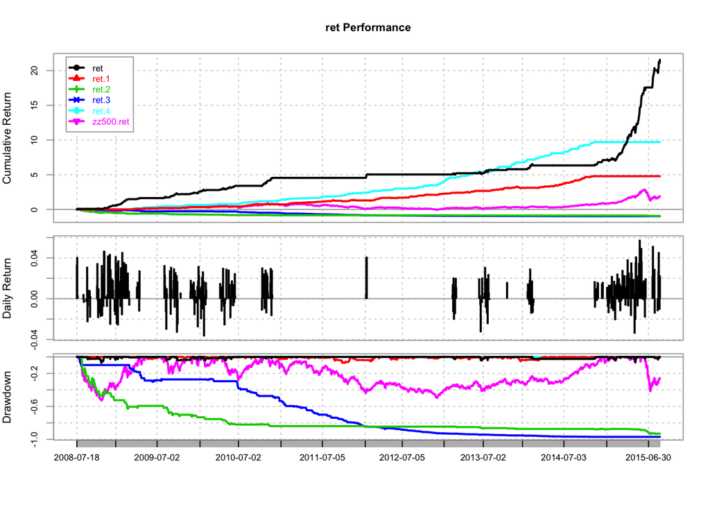

```r
ret_regimes <- cbind.xts(hmm$hmm_ret_regime, zz500$zz500.ret)
charts.PerformanceSummary(ret_regimes)
```

```r
table.Stats(ret_regimes)
```

```
##                       ret     ret.1     ret.2     ret.3     ret.4
## Observations    1592.0000 1592.0000 1592.0000 1592.0000 1592.0000
## NAs               10.0000   10.0000   10.0000   10.0000   10.0000
## Minimum           -0.0370   -0.0288   -0.0843   -0.0669   -0.0067
## Quartile 1         0.0000    0.0000    0.0000    0.0000    0.0000
## Median             0.0000    0.0000    0.0000    0.0000    0.0000
## Arithmetic Mean    0.0020    0.0011   -0.0016   -0.0022    0.0015
## Geometric Mean     0.0020    0.0011   -0.0017   -0.0022    0.0015
## Quartile 3         0.0000    0.0000    0.0000    0.0000    0.0000
## Maximum            0.0579    0.0274    0.0987    0.0517    0.0418
## SE Mean            0.0002    0.0001    0.0003    0.0002    0.0001
## LCL Mean (0.95)    0.0016    0.0008   -0.0022   -0.0026    0.0012
## UCL Mean (0.95)    0.0024    0.0014   -0.0009   -0.0018    0.0018
## Variance           0.0001    0.0000    0.0002    0.0001    0.0000
## Stdev              0.0089    0.0057    0.0134    0.0083    0.0057
## Skewness           1.9317    0.5895   -1.3591   -2.4366    3.9941
## Kurtosis           8.5004    4.8740   16.9126   11.6701   15.8520
##                 zz500.ret
## Observations    1602.0000
## NAs                0.0000
## Minimum           -0.0843
## Quartile 1        -0.0087
## Median             0.0026
## Arithmetic Mean    0.0009
## Geometric Mean     0.0007
## Quartile 3         0.0128
## Maximum            0.0987
## SE Mean            0.0005
## LCL Mean (0.95)   -0.0001
## UCL Mean (0.95)    0.0019
## Variance           0.0004
## Stdev              0.0203
## Skewness          -0.4888
## Kurtosis           2.2795
```

```r
rbind(table.AnnualizedReturns(ret_regimes), table.Distributions(ret_regimes), maxDrawdown(ret_regimes))
```

```
##                                   ret      ret.1      ret.2      ret.3
## Annualized Return          0.63750000 0.32040000 -0.3453000 -0.4259000
## Annualized Std Dev         0.14150000 0.08970000  0.2130000  0.1323000
## Annualized Sharpe (Rf=0%)  4.50570000 3.57130000 -1.6215000 -3.2194000
## Monthly Std Dev            0.00890000 0.00570000  0.0134000  0.0083000
## Skewness                   1.93170000 0.58950000 -1.3591000 -2.4366000
## Kurtosis                  11.50040000 7.87400000 19.9126000 14.6701000
## Excess kurtosis            8.50040000 4.87400000 16.9126000 11.6701000
## Sample skewness            1.93540000 0.59060000 -1.3617000 -2.4412000
## Sample excess kurtosis     8.53090000 4.89310000 16.9696000 11.7106000
## Worst Drawdown             0.07242604 0.06979631  0.9345179  0.9699646
##                                  ret.4 zz500.ret
## Annualized Return          0.455200000  0.188500
## Annualized Std Dev         0.090500000  0.321900
## Annualized Sharpe (Rf=0%)  5.033000000  0.585700
## Monthly Std Dev            0.005700000  0.020300
## Skewness                   3.994100000 -0.488800
## Kurtosis                  18.852000000  5.279500
## Excess kurtosis           15.852000000  2.279500
## Sample skewness            4.001700000 -0.489700
## Sample excess kurtosis    15.905700000  2.290400
## Worst Drawdown             0.006656765  0.530865
```